# Answers to Exercises: Let’s practice more GLMs

Alexandre Courtiol

2018-04-29

## Disclamer

In this vignette I illustrate the key steps required to solve the exercises. By no means I am trying to provide a detailed report of the analysis of each dataset. I am trying to put emphasis on different things you could do in the different exercise. Any final real report would need additional analyses and results would have to be written in good English, not in telegraphic style or lines of codes. I have also written this vignette very quickly, so double check I did not mess anything up…

# Dataset: InsectSprays

## Goal

- Compare the effectiveness of various insecticides on the number of insects in agricultural experimental units.
- What is the efficiency of spray C?
- Compare results between the LM approach (with and without BoxCox transformation) and the GLM approach.

Note: I will not check the assumptions for LM, nor detail the dataset (and plotting variables) since we did it before.

## Fitting the models

We fit the LM:

```r
mod_insect <- lm(count ~ spray, data = InsectSprays)
```

We fit the LM on the BoxCox transformed response:

```r
InsectSprays$count_bis <- InsectSprays$count + 1
mod_insect_bis <- update(mod_insect, count_bis ~ .)
bc <- car::powerTransform(mod_insect_bis)
InsectSprays$count_bc <- car::bcPower(InsectSprays$count_bis, bc$lambda)
mod_insect_bc <- update(mod_insect_bis, count_bc ~ .)
```

We fit the GLM:

```r
mod_insect_glm <- glm(count ~ spray, data = InsectSprays, family = poisson())
```

## Checking the assumptions for GLM

All assumptions about model structure have been checked before (see exercises for LM).

We still have to test for lack of serial auto-correlation and independance:

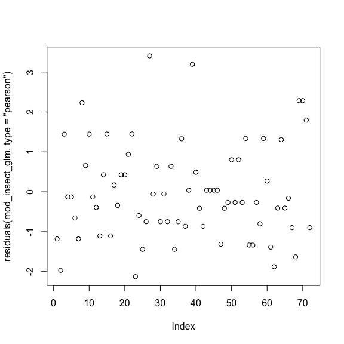

```r
plot(residuals(mod_insect_glm, type = "pearson"))
```

```
## DHARMa::plotResiduals - low number of unique predictor values, consider setting asFactor = T
## DHARMa::plotResiduals - low number of unique predictor values, consider setting asFactor = T
```

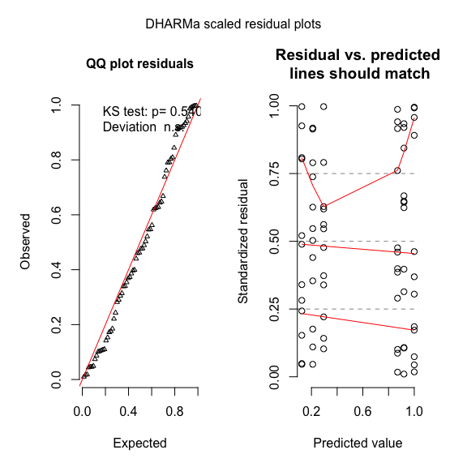

```r
library(DHARMa)
insect_glm_resid <- simulateResiduals(mod_insect_glm, refit = TRUE, n = 1000)
plot(insect_glm_resid)
```

```r
testUniformity(insect_glm_resid)
```

```
##
##  One-sample Kolmogorov-Smirnov test
##
## data:  simulationOutput$scaledResiduals
## D = 0.094556, p-value = 0.5404
## alternative hypothesis: two-sided
```

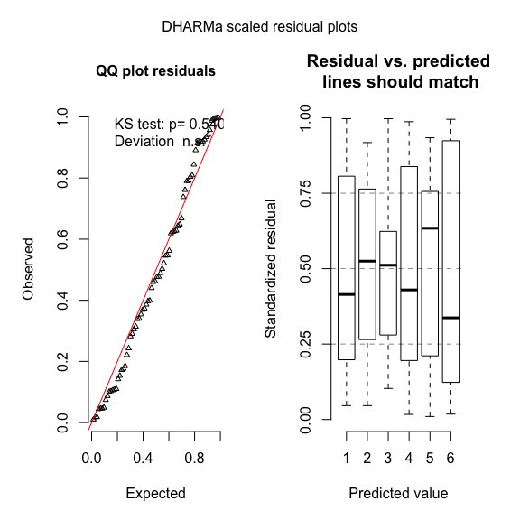

```r
plot(insect_glm_resid, asFactor = TRUE)
```

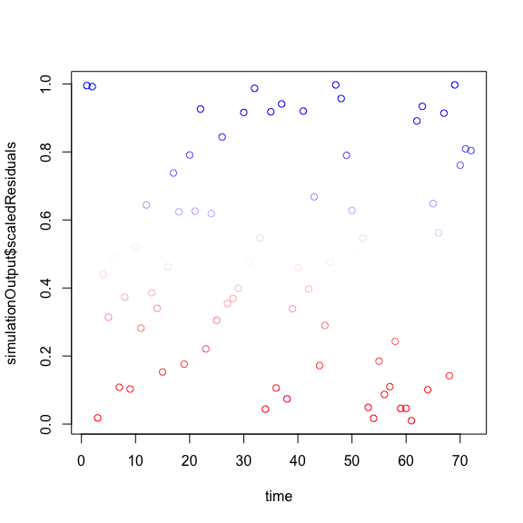

```
##
##  Durbin-Watson test
##
## data:  simulationOutput$scaledResiduals ~ 1
## DW = 1.8008, p-value = 0.1975
## alternative hypothesis: true autocorrelation is greater than 0
```

```r
testTemporalAutocorrelation(insect_glm_resid)
```

All look good. We also have to test for the goodness of fit:

```r
testOverdispersion(insect_glm_resid, alternative = "both")
```

```
##
##  DHARMa nonparametric overdispersion test via comparison to
##  simulation under H0 = fitted model
##
## data:  insect_glm_resid
## dispersion = 1.5104, p-value = 0.012
## alternative hypothesis: both
```

There seem to be slight overdispersion :-(

## Solving the overdispersion issue

Is the overdispersion caused by two many zeros?

```r
table(mod_insect_glm$model$count)
```

```
##
##  0  1  2  3  4  5  6  7  9 10 11 12 13 14 15 16 17 19 20 21 22 23 24 26
##  2  6  4  8  4  7  3  3  1  3  3  2  4  4  2  2  4  1  2  2  1  1  1  2
```

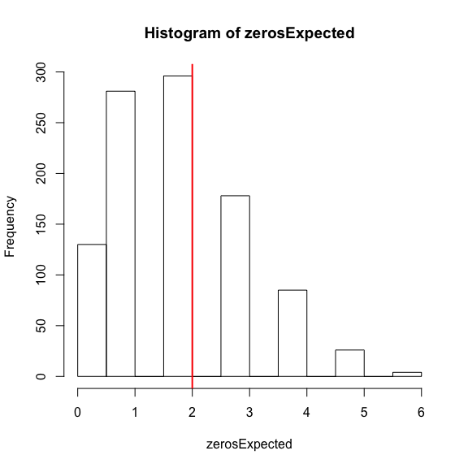

```
##
##  DHARMa zero-inflation test via comparison to expected zeros with
##  simulation under H0 = fitted model
##
## data:  insect_glm_resid
## ratioObsExp = 1.0521, p-value = 0.293
## alternative hypothesis: more
```

```r
testZeroInflation(insect_glm_resid)
```

nope…

Let’s try to fit alternative models to account for the overdispersion:

```r
mod_insect_glm_quasi <- glm(count ~ spray, data = InsectSprays, family = quasipoisson())
library(MASS)
mod_insect_glm_nb <- glm.nb(count ~ spray, data = InsectSprays)
rbind(deviance(mod_insect_glm),
      deviance(mod_insect_glm_quasi),
      deviance(mod_insect_glm_nb))
```

```
##          [,1]
## [1,] 98.32866
## [2,] 98.32866
## [3,] 74.14497
```

Note that the prediction are the same:

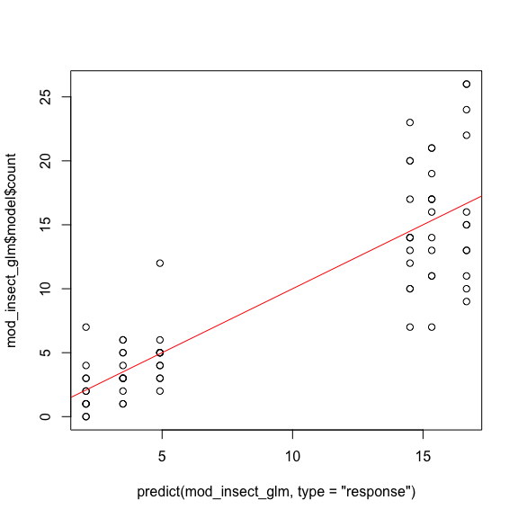

```r
plot(predict(mod_insect_glm, type = "response"), mod_insect_glm$model$count)
abline(0, 1, col = "red")
```

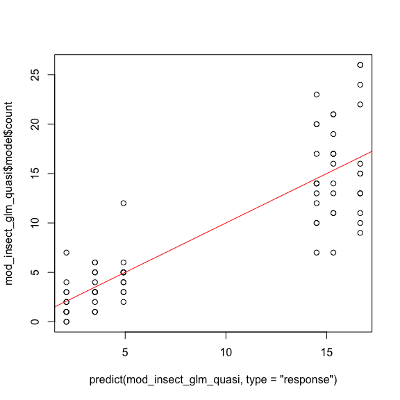

```r
plot(predict(mod_insect_glm_quasi, type = "response"), mod_insect_glm_quasi$model$count)
abline(0, 1, col = "red")
```

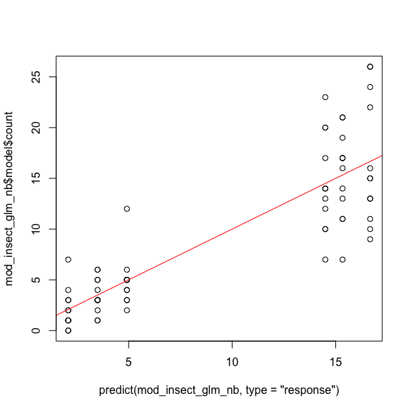

```r
plot(predict(mod_insect_glm_nb, type = "response"), mod_insect_glm_nb$model$count)
abline(0, 1, col = "red")
```

The only thing that differ is the variance around those predictions.

Note also that the gaussian models have deviance expressed on another scale, which makes the comparison between all models particularly difficult.

```r
pred_bc <- ((predict(mod_insect_bc) * bc$lambda) + 1)^(1/bc$lambda) - 1
(deviance_LM_bc <- sum((pred_bc - InsectSprays$count)^2))
```

```
## [1] 1028.846
```

```r
deviance(mod_insect)
```

```
## [1] 1015.167
```

We can compare the poisson model with the negative binomial one very simply:

```r
library(lmtest)
lrtest(mod_insect_glm_nb, mod_insect_glm)
```

```
## Likelihood ratio test
##
## Model 1: count ~ spray
## Model 2: count ~ spray
##   #Df  LogLik Df  Chisq Pr(>Chisq)
## 1   7 -180.11
## 2   6 -182.29 -1 4.3713    0.03655 *
## ---
## Signif. codes:  0 '***' 0.001 '**' 0.01 '*' 0.05 '.' 0.1 ' ' 1
```

Let us stick to the negative binomial model as our best GLM!

## Retesting assumptions on the negative binomial model

```r
insect_glm_nb_resid   <- simulateResiduals(mod_insect_glm_nb, refit = TRUE, n = 1000)
testUniformity(insect_glm_nb_resid)
```

```
##
##  One-sample Kolmogorov-Smirnov test
##
## data:  simulationOutput$scaledResiduals
## D = 0.076, p-value = 0.7999
## alternative hypothesis: two-sided
```

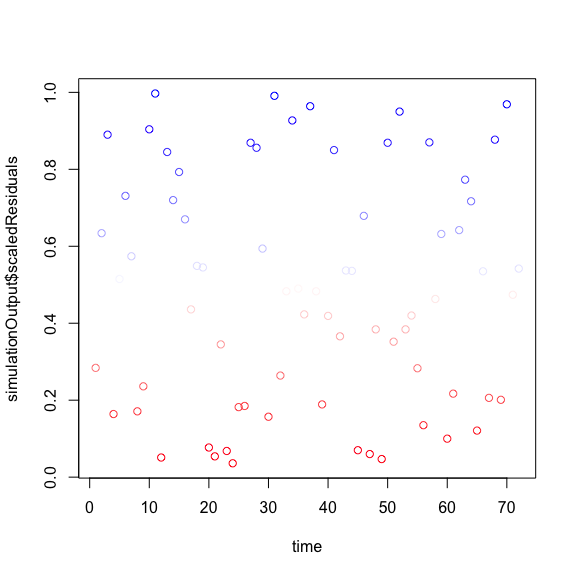

```
##
##  Durbin-Watson test
##
## data:  simulationOutput$scaledResiduals ~ 1
## DW = 2.1796, p-value = 0.7783
## alternative hypothesis: true autocorrelation is greater than 0
```

```r
testTemporalAutocorrelation(insect_glm_nb_resid)
```

```r
testOverdispersion(insect_glm_nb_resid, alternative = "both")
```

```
##
##  DHARMa nonparametric overdispersion test via comparison to
##  simulation under H0 = fitted model
##
## data:  insect_glm_nb_resid
## dispersion = 1.0673, p-value = 0.408
## alternative hypothesis: both
```

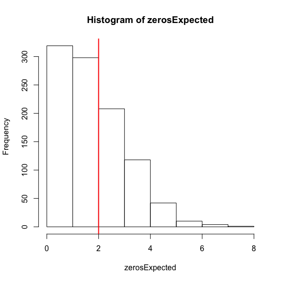

```
##
##  DHARMa zero-inflation test via comparison to expected zeros with
##  simulation under H0 = fitted model
##
## data:  insect_glm_nb_resid
## ratioObsExp = 0.89646, p-value = 0.383
## alternative hypothesis: more
```

```r
testZeroInflation(insect_glm_nb_resid)
```

Everything looks very good!

## Tests comparing the fitted models to their respective null models

```r
anova(mod_insect, update(mod_insect, . ~ 1))
```

```
## Analysis of Variance Table
##
## Model 1: count ~ spray
## Model 2: count ~ 1
##   Res.Df    RSS Df Sum of Sq      F    Pr(>F)
## 1     66 1015.2
## 2     71 3684.0 -5   -2668.8 34.702 < 2.2e-16 ***
## ---
## Signif. codes:  0 '***' 0.001 '**' 0.01 '*' 0.05 '.' 0.1 ' ' 1
```

```r
anova(mod_insect_bc, update(mod_insect_bc, . ~ 1))
```

```
## Analysis of Variance Table
##
## Model 1: count_bc ~ spray
## Model 2: count_bc ~ 1
##   Res.Df     RSS Df Sum of Sq      F    Pr(>F)
## 1     66  31.998
## 2     71 150.337 -5   -118.34 48.818 < 2.2e-16 ***
## ---
## Signif. codes:  0 '***' 0.001 '**' 0.01 '*' 0.05 '.' 0.1 ' ' 1
```

```r
anova(mod_insect_glm, update(mod_insect_glm, . ~ 1), test = "LR")
```

```
## Analysis of Deviance Table
##
## Model 1: count ~ spray
## Model 2: count ~ 1
##   Resid. Df Resid. Dev Df Deviance  Pr(>Chi)
## 1        66      98.33
## 2        71     409.04 -5  -310.71 < 2.2e-16 ***
## ---
## Signif. codes:  0 '***' 0.001 '**' 0.01 '*' 0.05 '.' 0.1 ' ' 1
```

```r
anova(mod_insect_glm_nb, update(mod_insect_glm_nb, . ~ 1))
```

```
## Likelihood ratio tests of Negative Binomial Models
##
## Response: count
##   Model     theta Resid. df    2 x log-lik.   Test    df LR stat. Pr(Chi)
## 1     1  1.736021        71       -467.9604
## 2 spray 28.099507        66       -360.2179 1 vs 2     5 107.7425       0
```

No matter the model the effect of the insecticed is detected!

## Predictions

We now compare the predictions and CI between the different models:

```r
data.for.pred <- data.frame(spray = levels(InsectSprays$spray))
pred_lm <- predict(mod_insect, newdata = data.for.pred, interval = "confidence")
pred_bc <- predict(mod_insect_bc, newdata = data.for.pred, interval = "confidence")
unboxcox <- function(x, lambda) (x*lambda + 1)^(1/lambda)
pred_bc_unboxcox <- unboxcox(x = pred_bc, lambda = bc$lambda) - 1  ## we remove one as we added one so to be able to do the BoxCox
pred_glm_eta <- predict(mod_insect_glm, newdata = data.for.pred, se.fit = TRUE)
pred_glm_table <- data.frame(fit = exp(pred_glm_eta$fit))
pred_glm_table$lwr <- exp(pred_glm_eta$fit + qnorm(0.025)*pred_glm_eta$se.fit)
pred_glm_table$upr <- exp(pred_glm_eta$fit + qnorm(0.975)*pred_glm_eta$se.fit)
pred_glm_nb_eta <- predict(mod_insect_glm_nb, newdata = data.for.pred, se.fit = TRUE)
pred_glm_nb_table <- data.frame(fit = spaMM::negbin()$linkinv(pred_glm_eta$fit))
pred_glm_nb_table$lwr <- spaMM::negbin()$linkinv(pred_glm_nb_eta$fit + qnorm(0.025)*pred_glm_nb_eta$se.fit)
pred_glm_nb_table$upr <- spaMM::negbin()$linkinv(pred_glm_nb_eta$fit + qnorm(0.975)*pred_glm_nb_eta$se.fit)
```

## Plot

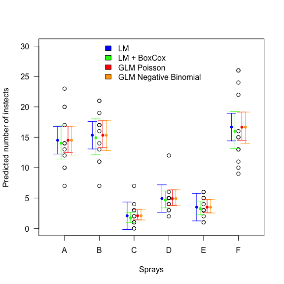

```r
plot(InsectSprays$count ~  as.numeric(InsectSprays$spray), xlim = c(0.5, 6.5), ylim = c(0, 30),
     ylab = "Predicted number of instects", xlab = "Sprays", axes = FALSE)
axis(2, las = 2)
axis(1, at = 1:6, labels = levels(InsectSprays$spray))
box()

points(pred_lm[, "fit"] ~  I(-0.2 + 1:6), col = "blue", pch = 20)

arrows(x0 = -0.2 + 1:6, x1 = -0.2 + 1:6, y0 = pred_lm[, "lwr"],
       y1 = pred_lm[, "upr"], code = 3, col = "blue", angle = 90, length = 0.1)

points(pred_bc_unboxcox[, "fit"] ~  I(-0.1 + 1:6), col = "green", pch = 20)

arrows(x0 = -0.1 + 1:6, x1 = -0.1 + 1:6, y0 = pred_bc_unboxcox[, "lwr"],
       y1 = pred_bc_unboxcox[, "upr"], code = 3, col = "green", angle = 90, length = 0.1)

points(pred_glm_table[, "fit"] ~  I(0.1 + 1:6), col = "red", pch = 20)

arrows(x0 = 0.1 + 1:6, x1 = 0.1 + 1:6, y0 = pred_glm_table[, "lwr"],
       y1 = pred_glm_table[, "upr"], code = 3, col = "red", angle = 90, length = 0.1)

points(pred_glm_nb_table[, "fit"] ~  I(0.2 + 1:6), col = "orange", pch = 20)

arrows(x0 = 0.2 + 1:6, x1 = 0.2 + 1:6, y0 = pred_glm_nb_table[, "lwr"],
       y1 = pred_glm_table[, "upr"], code = 3, col = "orange", angle = 90, length = 0.1)

legend("top", fill = c("blue", "green", "red", "orange"), legend = c("LM", "LM + BoxCox", "GLM Poisson", "GLM Negative Binomial"), bty = "n")
```

## Testing properly if BoxCox model is better than NegBin one

```r
set.seed(1L)
logLik_diff_H0 <- replicate(1000, {
  new.y <- round(((simulate(mod_insect_bc)[, 1] * bc$lambda) + 1)^(1/bc$lambda) - 1)
  new.y_plus <- new.y + abs(min(new.y)) - min(new.y + abs(min(new.y)))
  new.y_plus1 <- new.y_plus + 1
  mod_insect_bis <- lm(new.y_plus1 ~ spray, data = InsectSprays)
  bc_new <- car::powerTransform(mod_insect_bis)
  new.y_plus1_bc <- car::bcPower(new.y_plus1, bc_new$lambda)
  mod_insect_bc_new <- lm(new.y_plus1_bc ~ spray, data = InsectSprays)
  mod_insect_glm_nb_new <- glm.nb(new.y_plus ~ spray, data = InsectSprays)
  logLik(mod_insect_bc_new)[[1]] - logLik(mod_insect_glm_nb_new)[[1]]
  })
(logLik_diff_obs <- logLik(mod_insect_bc)[[1]] - logLik(mod_insect_glm_nb)[[1]])
```

```
## [1] 107.1409
```

```r
(sum(logLik_diff_obs < (logLik_diff_H0)) + 1) / (length(logLik_diff_H0) + 1)
```

```
## [1] 0.4075924
```

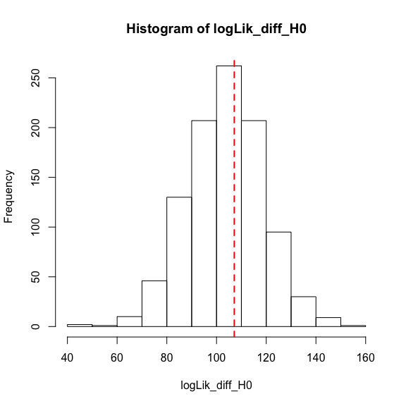

```r
hist(logLik_diff_H0, nclass = 10)
abline(v = logLik_diff_obs, col = "red", lwd = 2, lty = 2)
```

## Testing properly if NegBin model is better than BoxCox one

```r
set.seed(1L)
logLik_diff_H0 <- replicate(1000, {
  new.y <- simulate(mod_insect_glm_nb)[, 1]
  new.y_plus <- new.y + abs(min(new.y)) - min(new.y + abs(min(new.y)))
  new.y_plus1 <- new.y_plus + 1
  mod_insect_bis <- lm(new.y_plus1 ~ spray, data = InsectSprays)
  bc_new <- car::powerTransform(mod_insect_bis)
  new.y_plus1_bc <- car::bcPower(new.y_plus1, bc_new$lambda)
  mod_insect_bc_new <- lm(new.y_plus1_bc ~ spray, data = InsectSprays)
  mod_insect_glm_nb_new <- glm.nb(new.y ~ spray, data = InsectSprays)
  logLik(mod_insect_bc_new)[[1]] - logLik(mod_insect_glm_nb_new)[[1]]
  })
(logLik_diff_obs <- logLik(mod_insect_bc)[[1]] - logLik(mod_insect_glm_nb)[[1]])
```

```
## [1] 107.1409
```

```r
(sum(logLik_diff_obs < (logLik_diff_H0)) + 1) / (length(logLik_diff_H0) + 1)
```

```
## [1] 0.2237762
```

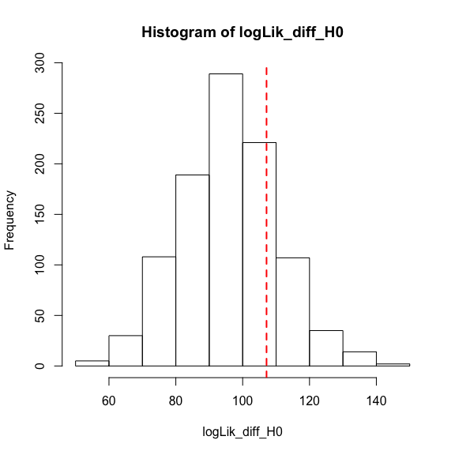

```r
hist(logLik_diff_H0, nclass = 10)
abline(v = logLik_diff_obs, col = "red", lwd = 2, lty = 2)
```

The two models do not differ, we could choose either!

This is not a general results. On other data LM on BoxCoxed data and a negative binomial fit of the data may greatly differ!!!

# Dataset: LM2GLMM::Surprise

## Goal

- Do children value more the type of the present, the cost of the present, or both?

## Solution

Try figuring out this one on your own! It’s all in the title.

# Dataset: esoph

## Goal

- Find out whether you should rather limit alcohol consumption or tabacco consumption in order to avoid developing an oesophageal cancer?

## Exploration of the data

```r
esoph
```

```
##    agegp     alcgp    tobgp ncases ncontrols
## 1  25-34 0-39g/day 0-9g/day      0        40
## 2  25-34 0-39g/day    10-19      0        10
## 3  25-34 0-39g/day    20-29      0         6
## 4  25-34 0-39g/day      30+      0         5
## 5  25-34     40-79 0-9g/day      0        27
## 6  25-34     40-79    10-19      0         7
## 7  25-34     40-79    20-29      0         4
## 8  25-34     40-79      30+      0         7
## 9  25-34    80-119 0-9g/day      0         2
## 10 25-34    80-119    10-19      0         1
## 11 25-34    80-119      30+      0         2
## 12 25-34      120+ 0-9g/day      0         1
## 13 25-34      120+    10-19      1         1
## 14 25-34      120+    20-29      0         1
```

[output cut: 74 more lines]

```r
str(esoph)
```

```
## 'data.frame':    88 obs. of  5 variables:
##  $ agegp    : Ord.factor w/ 6 levels "25-34"<"35-44"<..: 1 1 1 1 1 1 1 1 1 1 ...
##  $ alcgp    : Ord.factor w/ 4 levels "0-39g/day"<"40-79"<..: 1 1 1 1 2 2 2 2 3 3 ...
##  $ tobgp    : Ord.factor w/ 4 levels "0-9g/day"<"10-19"<..: 1 2 3 4 1 2 3 4 1 2 ...
##  $ ncases   : num  0 0 0 0 0 0 0 0 0 0 ...
##  $ ncontrols: num  40 10 6 5 27 7 4 7 2 1 ...
```

The factors are ordered which will select for different default contrast, so we set them as unordered:

```r
esoph$agegp_f <- factor(esoph$agegp, ordered = FALSE)
esoph$alcgp_f <- factor(esoph$alcgp, ordered = FALSE)
esoph$tobgp_f <- factor(esoph$tobgp, ordered = FALSE)
```

```r
summary(esoph)
```

```
##    agegp          alcgp         tobgp        ncases         ncontrols
##  25-34:15   0-39g/day:23   0-9g/day:24   Min.   : 0.000   Min.   : 1.00
##  35-44:15   40-79    :23   10-19   :24   1st Qu.: 0.000   1st Qu.: 3.00
##  45-54:16   80-119   :21   20-29   :20   Median : 1.000   Median : 6.00
##  55-64:16   120+     :21   30+     :20   Mean   : 2.273   Mean   :11.08
##  65-74:15                                3rd Qu.: 4.000   3rd Qu.:14.00
##  75+  :11                                Max.   :17.000   Max.   :60.00
##   agegp_f        alcgp_f       tobgp_f
##  25-34:15   0-39g/day:23   0-9g/day:24
##  35-44:15   40-79    :23   10-19   :24
##  45-54:16   80-119   :21   20-29   :20
##  55-64:16   120+     :21   30+     :20
##  65-74:15
##  75+  :11
```

```r
esoph$cancer_freq <- esoph$ncases / (esoph$ncases + esoph$ncontrols)
esoph$cancer_N <- esoph$ncases + esoph$ncontrols
summary(esoph$cancer_freq) ## proportion of cancer
```

```
##    Min. 1st Qu.  Median    Mean 3rd Qu.    Max.
##  0.0000  0.0000  0.2111  0.2089  0.3679  0.5000
```

```r
table(esoph$alcgp_f, esoph$tobgp_f)
```

```
##
##             0-9g/day 10-19 20-29 30+
##   0-39g/day        6     6     5   6
##   40-79            6     6     6   5
##   80-119           6     6     4   5
##   120+             6     6     5   4
```

```r
table(esoph$alcgp_f, esoph$tobgp_f, esoph$agegp_f)
```

```
## , ,  = 25-34
##
##
##             0-9g/day 10-19 20-29 30+
##   0-39g/day        1     1     1   1
##   40-79            1     1     1   1
##   80-119           1     1     0   1
##   120+             1     1     1   1
##
## , ,  = 35-44
##
##
##             0-9g/day 10-19 20-29 30+
##   0-39g/day        1     1     1   1
##   40-79            1     1     1   1
##   80-119           1     1     1   1
##   120+             1     1     1   0
##
## , ,  = 45-54
##
##
##             0-9g/day 10-19 20-29 30+
##   0-39g/day        1     1     1   1
##   40-79            1     1     1   1
##   80-119           1     1     1   1
##   120+             1     1     1   1
##
## , ,  = 55-64
##
##
##             0-9g/day 10-19 20-29 30+
##   0-39g/day        1     1     1   1
##   40-79            1     1     1   1
##   80-119           1     1     1   1
##   120+             1     1     1   1
##
## , ,  = 65-74
##
##
##             0-9g/day 10-19 20-29 30+
##   0-39g/day        1     1     1   1
##   40-79            1     1     1   0
##   80-119           1     1     1   1
##   120+             1     1     1   1
##
## , ,  = 75+
##
##
##             0-9g/day 10-19 20-29 30+
##   0-39g/day        1     1     0   1
##   40-79            1     1     1   1
##   80-119           1     1     0   0
##   120+             1     1     0   0
```

We plot the data:

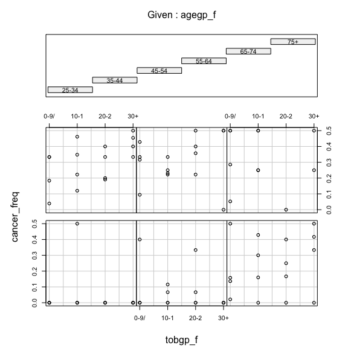

```r
coplot(cancer_freq ~ tobgp_f | agegp_f, data = esoph)
```

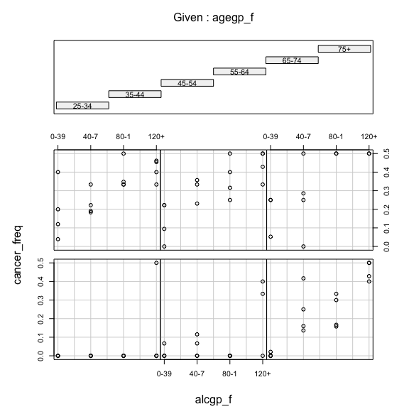

```r
coplot(cancer_freq ~ alcgp_f | agegp_f, data = esoph)
```

## We fit the models

```r
mod_esoph_logit <- glm(cbind(ncases, ncontrols) ~ agegp_f + alcgp_f + tobgp_f, data = esoph,
                       family = binomial(link = "logit"))
mod_esoph_cauchit <- glm(cbind(ncases, ncontrols) ~ agegp_f + alcgp_f + tobgp_f, data = esoph,
                         family = binomial(link = "cauchit"))
mod_esoph_probit <- glm(cbind(ncases, ncontrols) ~ agegp_f + alcgp_f + tobgp_f, data = esoph,
                        family = binomial(link = "probit"))
AIC(mod_esoph_logit)
```

```
## [1] 225.454
```

```r
AIC(mod_esoph_cauchit)
```

```
## [1] 242.4252
```

```r
AIC(mod_esoph_probit)
```

```
## [1] 221.825
```

The probit model fits the data best.

## Comparison to null model

```r
mod_esoph_probit_H0 <- glm(cbind(ncases, ncontrols) ~ 1, data = esoph,
                           family = binomial(link = "probit"))
anova(mod_esoph_probit, mod_esoph_probit_H0, test = "LR")
```

```
## Analysis of Deviance Table
##
## Model 1: cbind(ncases, ncontrols) ~ agegp_f + alcgp_f + tobgp_f
## Model 2: cbind(ncases, ncontrols) ~ 1
##   Resid. Df Resid. Dev  Df Deviance  Pr(>Chi)
## 1        76     50.344
## 2        87    227.241 -11   -176.9 < 2.2e-16 ***
## ---
## Signif. codes:  0 '***' 0.001 '**' 0.01 '*' 0.05 '.' 0.1 ' ' 1
```

The model is much better than a null model!

## Testing the model assumptions

```r
esoph_probit_resid <- simulateResiduals(mod_esoph_probit, refit = TRUE, n = 1000)
```

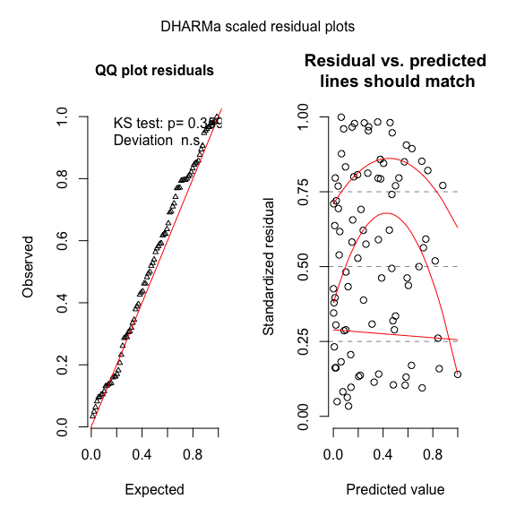

```r
plot(esoph_probit_resid)
```

```r
testUniformity(esoph_probit_resid)
```

```
##
##  One-sample Kolmogorov-Smirnov test
##
## data:  simulationOutput$scaledResiduals
## D = 0.098545, p-value = 0.3599
## alternative hypothesis: two-sided
```

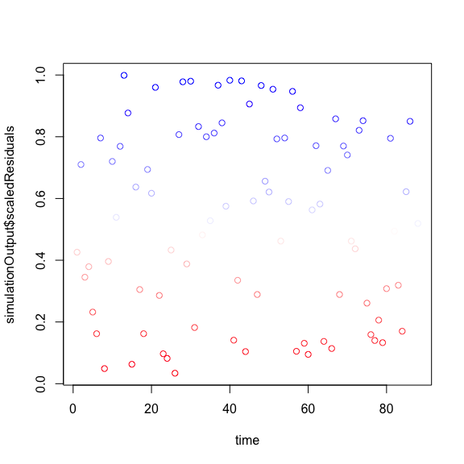

```
##
##  Durbin-Watson test
##
## data:  simulationOutput$scaledResiduals ~ 1
## DW = 2.0787, p-value = 0.6445
## alternative hypothesis: true autocorrelation is greater than 0
```

```r
testTemporalAutocorrelation(esoph_probit_resid, time = 1:nrow(esoph))
```

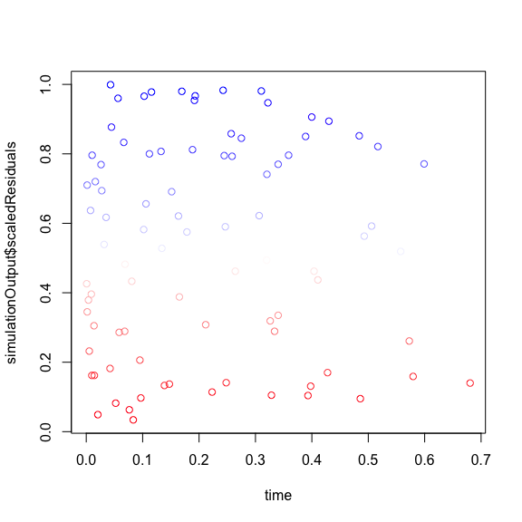

```
##
##  Durbin-Watson test
##
## data:  simulationOutput$scaledResiduals ~ 1
## DW = 2.0433, p-value = 0.5807
## alternative hypothesis: true autocorrelation is greater than 0
```

```r
testTemporalAutocorrelation(esoph_probit_resid, time = mod_esoph_probit$fitted.values)
```

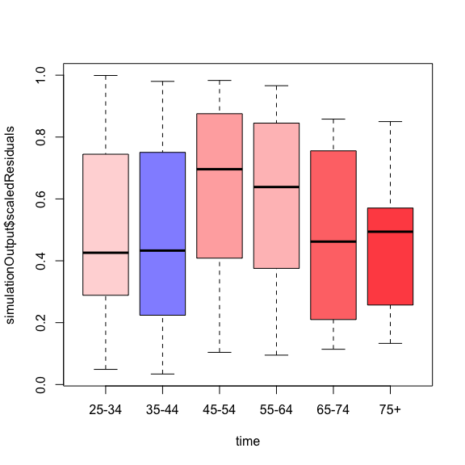

```
##
##  Durbin-Watson test
##
## data:  simulationOutput$scaledResiduals ~ 1
## DW = 2.0787, p-value = 0.6445
## alternative hypothesis: true autocorrelation is greater than 0
```

```r
testTemporalAutocorrelation(esoph_probit_resid, time = mod_esoph_probit$model$agegp_f) ## useful??
```

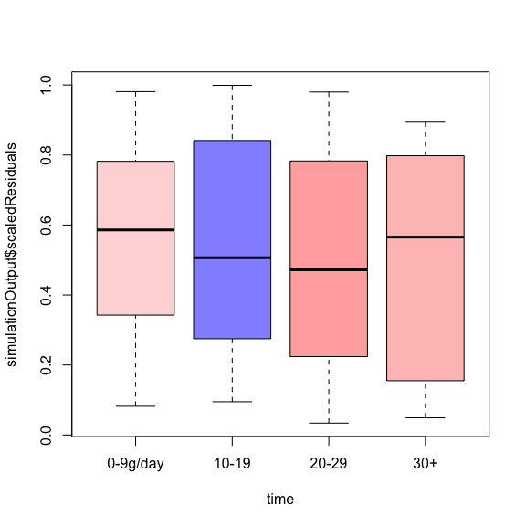

```
##
##  Durbin-Watson test
##
## data:  simulationOutput$scaledResiduals ~ 1
## DW = 2.2095, p-value = 0.8385
## alternative hypothesis: true autocorrelation is greater than 0
```

```r
testTemporalAutocorrelation(esoph_probit_resid, time = mod_esoph_probit$model$tobgp_f) ## useful??
```

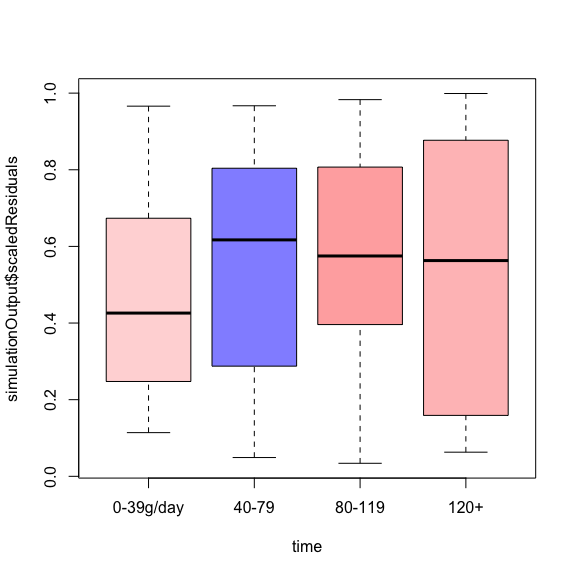

```
##
##  Durbin-Watson test
##
## data:  simulationOutput$scaledResiduals ~ 1
## DW = 1.9536, p-value = 0.4135
## alternative hypothesis: true autocorrelation is greater than 0
```

```r
testTemporalAutocorrelation(esoph_probit_resid, time = mod_esoph_probit$model$alcgp_f) ## useful??
```

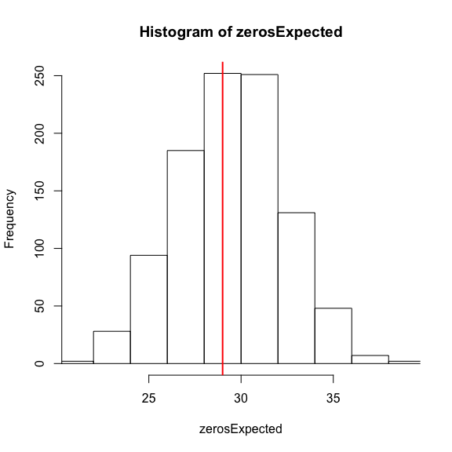

```
##
##  DHARMa zero-inflation test via comparison to expected zeros with
##  simulation under H0 = fitted model
##
## data:  esoph_probit_resid
## ratioObsExp = 0.96783, p-value = 0.576
## alternative hypothesis: more
```

```r
testZeroInflation(esoph_probit_resid)
```

```r
testOverdispersion(esoph_probit_resid, alternative = "both")
```

```
##
##  DHARMa nonparametric overdispersion test via comparison to
##  simulation under H0 = fitted model
##
## data:  esoph_probit_resid
## dispersion = 0.74473, p-value = 0.17
## alternative hypothesis: both
```

## Testing the model effects

```r
Anova(mod_esoph_probit)
```

```
## Analysis of Deviance Table (Type II tests)
##
## Response: cbind(ncases, ncontrols)
##         LR Chisq Df Pr(>Chisq)
## agegp_f   80.109  5  7.961e-16 ***
## alcgp_f   69.533  3  5.373e-15 ***
## tobgp_f   11.593  3   0.008915 **
## ---
## Signif. codes:  0 '***' 0.001 '**' 0.01 '*' 0.05 '.' 0.1 ' ' 1
```

## Plotting the effects

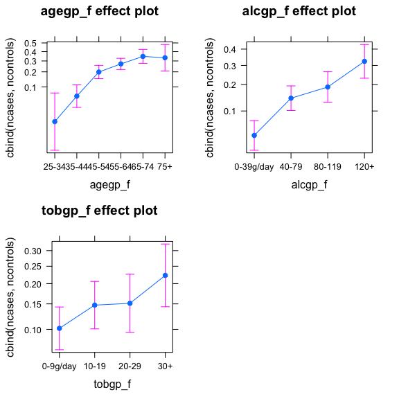

```r
library(effects)
plot(allEffects(mod_esoph_probit))
```

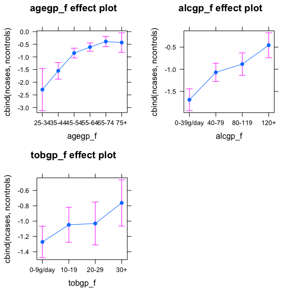

```r
plot(allEffects(mod_esoph_probit, transformation = list(link = NULL, inverse = NULL)))
```

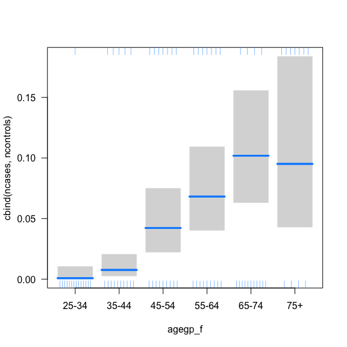

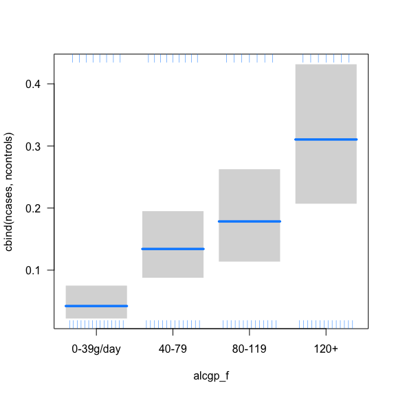

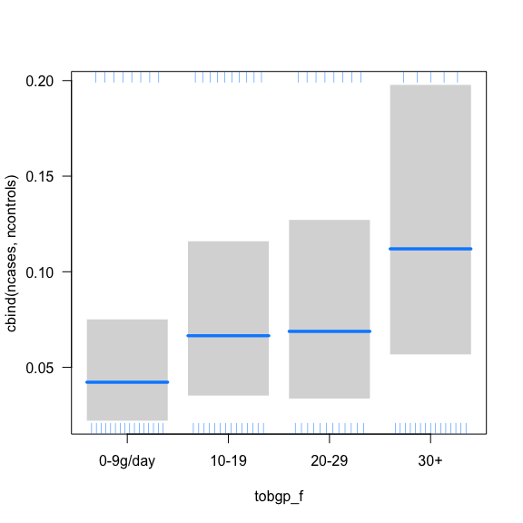

```r
library(visreg)
visreg(mod_esoph_probit, scale = "response")
```

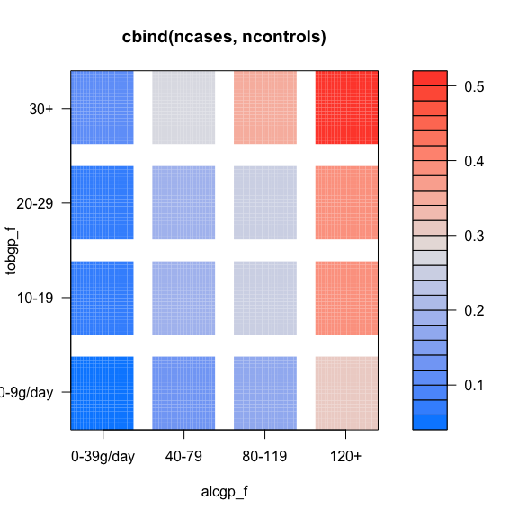

```r
visreg2d(mod_esoph_probit, "alcgp_f", "tobgp_f", plot.type = "image", scale = "response")
```

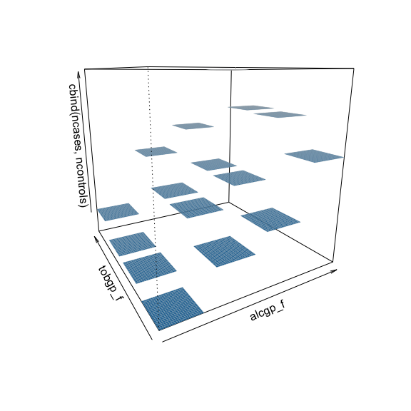

```r
visreg2d(mod_esoph_probit, "alcgp_f", "tobgp_f", plot.type = "persp", scale = "response")
```

Note: the two packages differ in how they compute predictions. The package effects seems to here compute the average effect of the non focal factor by weighing them by their sample size. The package visreg seems to here select the level with the highest number of observation for the non focal factor. I am not sure what it does when there are equalities in sample size… Doing predictions yourself is perhaps the easiest way to know what is actually happening!

## Predictions by hand

Let us compare extreme situations

```r
newdata_esoph_young <- expand.grid(agegp_f = c("25-34"),
                                   alcgp_f = c("0-39g/day", "120+"),
                                   tobgp_f = c("0-9g/day", "30+"))
pred_esoph_young <- predict(mod_esoph_probit, newdata = newdata_esoph_young, type = "link", se.fit = TRUE)
newdata_esoph_young$pred <- binomial(link = "probit")$linkinv(pred_esoph_young$fit)
newdata_esoph_young$lwr <- binomial(link = "probit")$linkinv(pred_esoph_young$fit + qnorm(0.025)*pred_esoph_young$se.fit)
newdata_esoph_young$upr <- binomial(link = "probit")$linkinv(pred_esoph_young$fit + qnorm(0.975)*pred_esoph_young$se.fit)
newdata_esoph_young
```

```
##   agegp_f   alcgp_f  tobgp_f         pred          lwr        upr
## 1   25-34 0-39g/day 0-9g/day 0.0007619471 0.0000273923 0.01055611
## 2   25-34      120+ 0-9g/day 0.0262383385 0.0024738469 0.14276353
## 3   25-34 0-39g/day      30+ 0.0039002480 0.0002025362 0.03717823
## 4   25-34      120+      30+ 0.0764025052 0.0106660728 0.28864986
```

```r
newdata_esoph_old <- expand.grid(agegp_f = c("75+"),
                                 alcgp_f = c("0-39g/day", "120+"),
                                 tobgp_f = c("0-9g/day", "30+"))
pred_esoph_old <- predict(mod_esoph_probit, newdata = newdata_esoph_old, type = "link", se.fit = TRUE)
newdata_esoph_old$pred <- binomial(link = "probit")$linkinv(pred_esoph_old$fit)
newdata_esoph_old$lwr <- binomial(link = "probit")$linkinv(pred_esoph_old$fit + qnorm(0.025)*pred_esoph_old$se.fit)
newdata_esoph_old$upr <- binomial(link = "probit")$linkinv(pred_esoph_old$fit + qnorm(0.975)*pred_esoph_old$se.fit)
newdata_esoph_old
```

```
##   agegp_f   alcgp_f  tobgp_f       pred       lwr       upr
## 1     75+ 0-39g/day 0-9g/day 0.09511196 0.0427947 0.1838748
## 2     75+      120+ 0-9g/day 0.46850630 0.2953570 0.6479350
## 3     75+ 0-39g/day      30+ 0.21173725 0.1003285 0.3740544
## 4     75+      120+      30+ 0.66657817 0.4708055 0.8249030
```

So alcool seems to be a bit worse than smoking but we are extrapolating a bit since very few individuals correspond to the predicted conditions! (see `table()` call above)

One thing is clear, not smoking and not drinking seems to be the way to avoid these cancers.

## Trying to fit the interaction to answer our question

```r
esoph$drink_smoke <- factor(paste(esoph$alcgp_f, esoph$tobgp_f, sep = "_"))
mod_esoph_probit2 <- glm(cbind(ncases, ncontrols) ~ agegp_f + drink_smoke, data = esoph,
                        family = binomial(link = "probit"))
Anova(mod_esoph_probit2)
```

```
## Analysis of Deviance Table (Type II tests)
##
## Response: cbind(ncases, ncontrols)
##             LR Chisq Df Pr(>Chisq)
## agegp_f       79.061  5  1.319e-15 ***
## drink_smoke   94.224 15  1.606e-13 ***
## ---
## Signif. codes:  0 '***' 0.001 '**' 0.01 '*' 0.05 '.' 0.1 ' ' 1
```

```r
summary(mod_esoph_probit2)
```

```
##
## Call:
## glm(formula = cbind(ncases, ncontrols) ~ agegp_f + drink_smoke,
##     family = binomial(link = "probit"), data = esoph)
##
## Deviance Residuals:
##     Min       1Q   Median       3Q      Max
## -1.8509  -0.5300  -0.2056   0.2616   1.9162
##
## Coefficients:
##                            Estimate Std. Error z value Pr(>|z|)
## (Intercept)                 -3.3734     0.4531  -7.446 9.62e-14 ***
## agegp_f35-44                 0.7288     0.4542   1.604 0.108615
## agegp_f45-54                 1.4536     0.4333   3.355 0.000794 ***
## agegp_f55-64                 1.6772     0.4305   3.896 9.78e-05 ***
## agegp_f65-74                 1.9048     0.4355   4.373 1.22e-05 ***
## agegp_f75+                   1.8491     0.4675   3.955 7.64e-05 ***
## drink_smoke0-39g/day_10-19   0.5839     0.2418   2.415 0.015737 *
## drink_smoke0-39g/day_20-29   0.5995     0.3065   1.956 0.050454 .
## drink_smoke0-39g/day_30+     0.9204     0.3302   2.787 0.005320 **
## drink_smoke120+_0-9g/day     1.5668     0.2609   6.006 1.90e-09 ***
## drink_smoke120+_10-19        1.6410     0.2891   5.676 1.38e-08 ***
## drink_smoke120+_20-29        1.7381     0.3495   4.973 6.58e-07 ***
## drink_smoke120+_30+          1.6849     0.3173   5.311 1.09e-07 ***
## drink_smoke40-79_0-9g/day    0.8609     0.1939   4.441 8.95e-06 ***
## drink_smoke40-79_10-19       0.9881     0.2234   4.423 9.71e-06 ***
## drink_smoke40-79_20-29       1.0136     0.2341   4.329 1.50e-05 ***
## drink_smoke40-79_30+         1.3801     0.2923   4.721 2.34e-06 ***
## drink_smoke80-119_0-9g/day   1.0703     0.2257   4.743 2.11e-06 ***
## drink_smoke80-119_10-19      1.1832     0.2303   5.137 2.80e-07 ***
## drink_smoke80-119_20-29      1.1478     0.3330   3.447 0.000566 ***
## drink_smoke80-119_30+        1.5511     0.3470   4.470 7.83e-06 ***
## ---
## Signif. codes:  0 '***' 0.001 '**' 0.01 '*' 0.05 '.' 0.1 ' ' 1
##
## (Dispersion parameter for binomial family taken to be 1)
##
##     Null deviance: 227.241  on 87  degrees of freedom
## Residual deviance:  44.889  on 67  degrees of freedom
## AIC: 234.37
##
## Number of Fisher Scoring iterations: 6
```

Ideally we should again check all assumptions (you should do it!).

Let us do the minimum here:

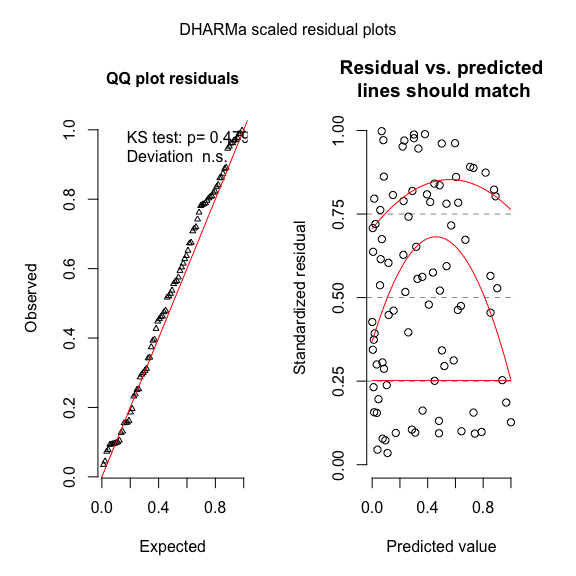

```r
plot(simulateResiduals(mod_esoph_probit2, refit = TRUE, n = 1000))
```

Let us now compare the alcool and drink effects.

```r
library(multcomp)
table(esoph$drink_smoke)
```

```
##
## 0-39g/day_0-9g/day    0-39g/day_10-19    0-39g/day_20-29
##                  6                  6                  5
##      0-39g/day_30+      120+_0-9g/day         120+_10-19
##                  6                  6                  6
##         120+_20-29           120+_30+     40-79_0-9g/day
##                  5                  4                  6
##        40-79_10-19        40-79_20-29          40-79_30+
##                  6                  6                  5
##    80-119_0-9g/day       80-119_10-19       80-119_20-29
##                  6                  6                  4
##         80-119_30+
##                  5
```

```r
contr_base <- matrix(c(1, rep(0, 15)), nrow = 1) ## define the desing matrix for the posthoc test
contr <- contr_base
contr[levels(esoph$drink_smoke) == "120+_0-9g/day"] <- 1
contr[levels(esoph$drink_smoke) == "0-39g/day_30+"] <- -1
colnames(contr) <- levels(esoph$drink_smoke)
rownames(contr) <- "alcool - smoke"
contr
```

```
##                0-39g/day_0-9g/day 0-39g/day_10-19 0-39g/day_20-29
## alcool - smoke                  1               0               0
##                0-39g/day_30+ 120+_0-9g/day 120+_10-19 120+_20-29 120+_30+
## alcool - smoke            -1             1          0          0        0
##                40-79_0-9g/day 40-79_10-19 40-79_20-29 40-79_30+
## alcool - smoke              0           0           0         0
##                80-119_0-9g/day 80-119_10-19 80-119_20-29 80-119_30+
## alcool - smoke               0            0            0          0
```

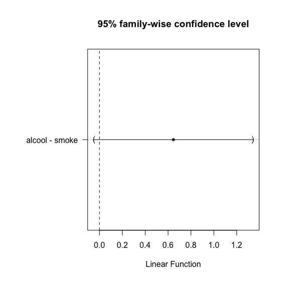

```r
posthoc <- glht(mod_esoph_probit2, linfct = mcp(drink_smoke = contr))
par(oma = c(1, 5, 1, 1))
plot(posthoc)
```

```r
confint(posthoc)
```

```
##
##   Simultaneous Confidence Intervals
##
## Multiple Comparisons of Means: User-defined Contrasts
##
##
## Fit: glm(formula = cbind(ncases, ncontrols) ~ agegp_f + drink_smoke,
##     family = binomial(link = "probit"), data = esoph)
##
## Quantile = 1.96
## 95% family-wise confidence level
##
##
## Linear Hypotheses:
##                     Estimate lwr      upr
## alcool - smoke == 0  0.64643 -0.04785  1.34071
```

```r
summary(posthoc, test = Chisqtest()) ## choose tests the better suited to your case
```

```
##
##   General Linear Hypotheses
##
## Multiple Comparisons of Means: User-defined Contrasts
##
##
## Linear Hypotheses:
##                     Estimate
## alcool - smoke == 0   0.6464
##
## Global Test:
##   Chisq DF Pr(>Chisq)
## 1  3.33  1    0.06802
```

We have compared two different situations, using a posthoc approach.